# Lab 3 Individual 1

Nicholas Heger

9/22/2020

1. Find the average years of education for the respondents with each political party affiliation. Arrange your output in a meaningful order and print. Describe any patterns you find.

```r
education <- dat[c('Political.party.affiliation', 'Highest.year.of.school.completed')]
education <- filter(education, education$Highest.year.of.school.completed != 'No answer')
education <- filter(education, education$Highest.year.of.school.completed != "Don't know")
education$Highest.year.of.school.completed <- as.numeric(education$Highest.year.of.school.completed)
education <- aggregate(education$Highest.year.of.school.completed,list(education$Political.party.affiliation), FUN = mean)
education
```

```
##               Group.1        x
## 1          Don't know 10.90909
## 2        Ind,near dem 13.20671
## 3        Ind,near rep 13.29531
## 4         Independent 12.31946
## 5           No answer 12.27913
## 6    Not str democrat 12.61759
## 7  Not str republican 13.25678
## 8         Other party 13.43324
## 9     Strong democrat 12.47403
## 10  Strong republican 13.44067
```

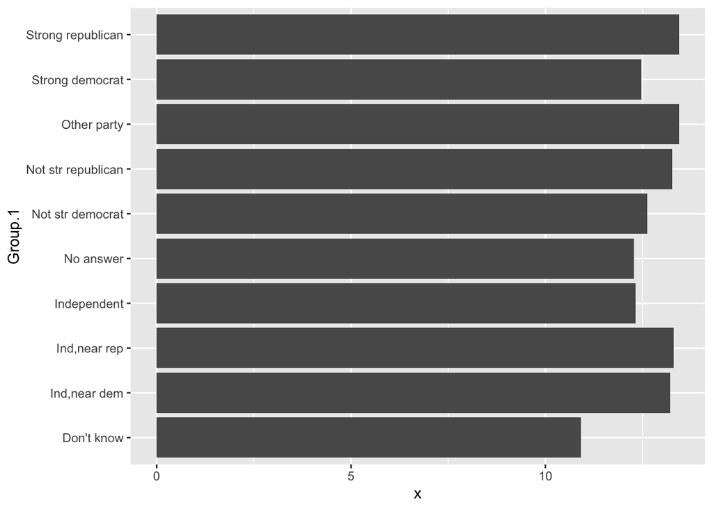

```r
ggplot(education, aes(x=Group.1, y=x)) + geom_bar(stat = "identity") + coord_flip()
```

According to the above table of the mean years of education of people from each party, people who do not know their political party tend to have significantly fewer years of education than any other group. Another trend is that republicans tend to have more years of education than democrats also.

2. Create a single data frame containing records for the better educated respondents in each political party affiliation. A “better educated” respondent is someone who has strictly more years of education than the median in the same party affiliation. Print the structure of the data frame.

```r
better_educated <- datnumeric %>%
  select(Political.party.affiliation, Highest.year.of.school.completed) %>%
  drop_na %>%
  group_by(Political.party.affiliation) %>%
  mutate(Highest.year.of.school.completed = as.numeric(Highest.year.of.school.completed, na.rm=TRUE)) %>%
  filter(Highest.year.of.school.completed > median(Highest.year.of.school.completed, na.rm=TRUE))
str(better_educated)
```

```
## tibble [27,840 × 2] (S3: grouped_df/tbl_df/tbl/data.frame)
##  $ Political.party.affiliation     : chr [1:27840] "Ind,near dem" "Not str democrat" "Ind,near dem" "Ind,near dem" ...
##  $ Highest.year.of.school.completed: num [1:27840] 16 17 14 16 13 14 14 17 14 16 ...
##  - attr(*, "groups")= tibble [10 × 2] (S3: tbl_df/tbl/data.frame)
##   ..$ Political.party.affiliation: chr [1:10] "Don't know" "Ind,near dem" "Ind,near rep" "Independent" ...
##   ..$ .rows                      : list<int> [1:10]
##   .. ..$ : int [1:5] 837 1083 1137 1262 23661
##   .. ..$ : int [1:3257] 1 3 4 8 16 19 27 35 41 47 ...
##   .. ..$ : int [1:2456] 7 9 11 21 43 53 56 58 59 68 ...
##   .. ..$ : int [1:3852] 23 29 45 48 49 57 62 78 79 102 ...
##   .. ..$ : int [1:148] 299 519 689 897 1007 1102 1191 1482 1513 1648 ...
##   .. ..$ : int [1:5692] 2 13 15 25 28 31 36 38 44 46 ...
##   .. ..$ : int [1:4322] 14 18 20 24 30 33 42 52 65 71 ...
##   .. ..$ : int [1:520] 22 26 61 89 99 111 151 154 192 376 ...
##   .. ..$ : int [1:4537] 5 6 12 17 37 39 40 74 75 76 ...
##   .. ..$ : int [1:3051] 10 32 34 50 51 64 66 88 100 127 ...
##   .. ..@ ptype: int(0)
##   ..- attr(*, ".drop")= logi TRUE
```

3. How is the happiness of a respondent related to his/her marriage status? Define that a person is happy if the response to question is “Very happy” or “Pretty happy”.

```r
happinessVSmarriage <- dat %>%
  select(General.happiness, Marital.status) %>%
  drop_na %>%
  filter(Marital.status != 'No Answer' & Marital.status != 'No answer' & General.happiness != "Don't know" & General.happiness != "No answer" & General.happiness != 'Not applicable') %>%
  mutate(Marital.status = factor(Marital.status, levels = c('Never married', 'Divorced', 'Seperated', 'Widowed', 'Married'))) %>%
  arrange(Marital.status)
summary(happinessVSmarriage)
```

```
##  General.happiness        Marital.status
##  Length:60034       Never married:12741
##  Class :character   Divorced     : 7630
##  Mode  :character   Seperated    :    0
##                     Widowed      : 5815
##                     Married      :31773
##                     NA's         : 2075
```

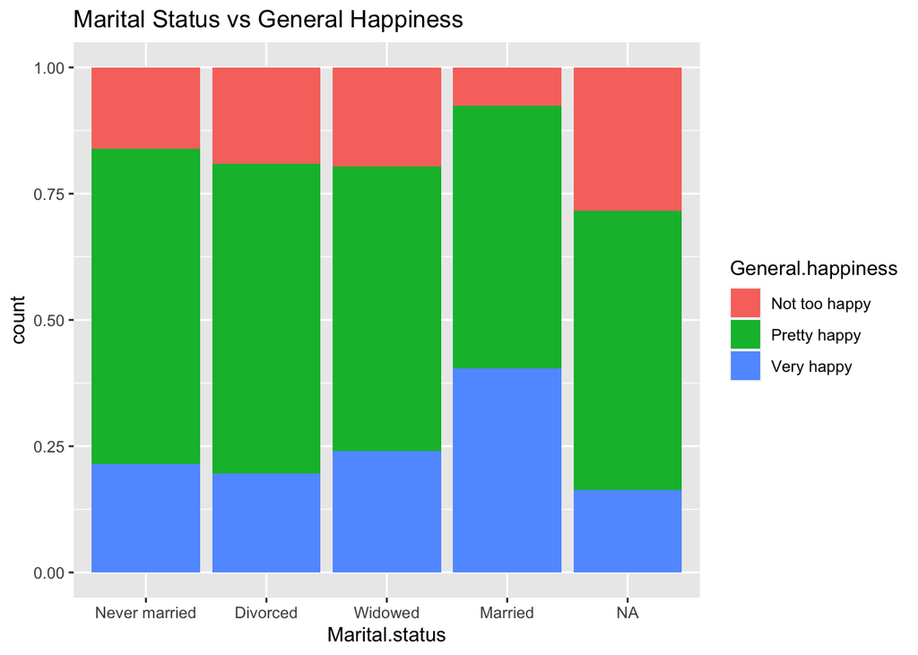

```r
ggplot(happinessVSmarriage, aes(x=Marital.status, fill=General.happiness)) + geom_bar(position = 'fill') + ggtitle("Marital Status vs General Happiness")
```

From the above data, it appears that the happiest group of individuals are married people. Married people have by far the highest percentage of very happy respondents and the lowest percentage of not too happy respondents. Widowed had the lowest happiness level overall, but the second highest in the very happy category. The variables I used were the marital status and general happiness variables.

4. Does party affiliation affect the relationship you found in the last question?

```r
happinessVSmarriageVSparty <- dat %>%
  select(General.happiness, Marital.status, Political.party.affiliation) %>%
  drop_na %>%
  filter(Marital.status != 'No Answer' & Marital.status != 'No answer' & General.happiness != "Don't know" & General.happiness != "No answer" & General.happiness != 'Not applicable' & Political.party.affiliation != "Don't know" & Political.party.affiliation != "No answer" & Political.party.affiliation != 'Not applicable') %>%
  mutate(Marital.status = factor(Marital.status, levels = c('Never married', 'Divorced', 'Seperated', 'Widowed', 'Married'))) %>%
  arrange(Marital.status)
summary(happinessVSmarriageVSparty)
```

```
##  General.happiness        Marital.status  Political.party.affiliation
##  Length:59682       Never married:12668   Length:59682
##  Class :character   Divorced     : 7579   Class :character
##  Mode  :character   Seperated    :    0   Mode  :character
##                     Widowed      : 5770
##                     Married      :31604
##                     NA's         : 2061
```

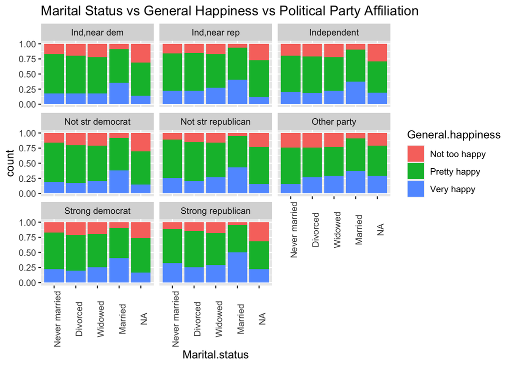

```r
ggplot(happinessVSmarriageVSparty, aes(x=Marital.status, fill=General.happiness)) + geom_bar(position = 'fill') + facet_wrap(~happinessVSmarriageVSparty$Political.party.affiliation) + theme(axis.text.x=element_text(angle=90))+ ggtitle("Marital Status vs General Happiness vs Political Party Affiliation")
```

Looking at the above data, it does not appear that party really has an impact on happiness. Across the political party charts it seems happiness is very similar and depends more on marital status, however republicans do tend to have ever so slightly higher levels of general happiness. The variables I used for this one were general happiness, political party affiliation, and marital status.

5. How is marital status related to the education of a respondent? What are possible reasons accounting for the patterns you see?

```r
marriageVSeducation <- datnumeric %>%
  select(Highest.year.of.school.completed, Marital.status) %>%
  drop_na %>%
  filter(Marital.status != 'No Answer' & Marital.status != 'No answer') %>%
  mutate(Marital.status = factor(Marital.status, levels = c('Never married', 'Divorced', 'Seperated', 'Widowed', 'Married'))) %>%
  arrange(Marital.status)
summary(marriageVSeducation)
```

```
##  Highest.year.of.school.completed       Marital.status
##  Min.   : 0.00                    Never married:13801
##  1st Qu.:12.00                    Divorced     : 8363
##  Median :12.00                    Seperated    :    0
##  Mean   :12.87                    Widowed      : 6164
##  3rd Qu.:15.00                    Married      :34053
##  Max.   :20.00                    NA's         : 2233
```

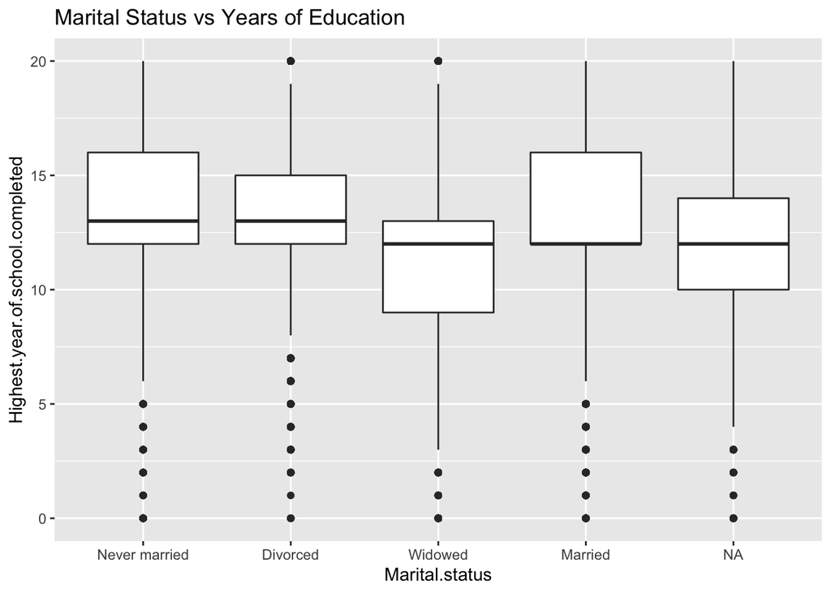

```r
ggplot(marriageVSeducation, aes(x=Marital.status, y=Highest.year.of.school.completed)) + geom_boxplot() + ggtitle("Marital Status vs Years of Education")
```

Looking at the above boxplot we can see that widowed people tend to have fewer years of education than the other martial status groups. My hypothesis as to why this is seen here is that widowed people are likely to be older, and went to school in different times when not as many people went to school for as long. The variables I used for this are highest year of school completed and marital status.

6. Explore two more interesting questions, and answer those questions using the GSS data.

```r
happinessVSrace <- dat %>%
  select(General.happiness, Race.of.respondent) %>%
  drop_na %>%
  filter(General.happiness != "Don't know" & General.happiness != "No answer" & General.happiness != 'Not applicable') %>%
  mutate(Race.of.respondent = factor(Race.of.respondent, levels = c('White', 'Black'))) %>%
  arrange(Race.of.respondent)
summary(happinessVSrace)
```

```
##  General.happiness  Race.of.respondent
##  Length:60054       White:48416
##  Class :character   Black: 8443
##  Mode  :character   NA's : 3195
```

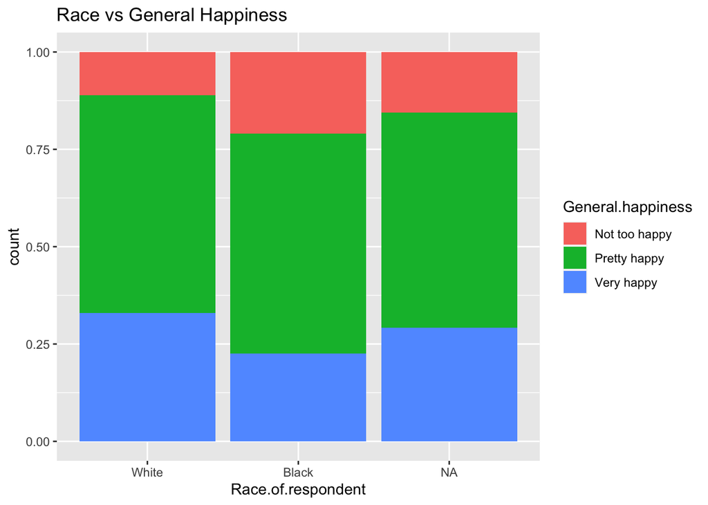

```r
ggplot(happinessVSrace, aes(x=Race.of.respondent, fill=General.happiness)) + geom_bar(position = 'fill') + ggtitle("Race vs General Happiness")
```

For our first extra variable, we decided to look at race vs general happiness. As we can see above, white respondents tended to have a higher level of general happiness than black respondents. For this analysis we used the general happiness and race of respondents variables.

```r
happinessVSage <- datnumeric %>%
  select(General.happiness, Age.of.respondent) %>%
  drop_na %>%
  filter(General.happiness != "Don't know" & General.happiness != "No answer" & General.happiness != 'Not applicable') %>%
  mutate(Age.of.respondent = as.numeric(Age.of.respondent, na.rm=TRUE)) %>%
  mutate(bin = cut(Age.of.respondent, breaks=c(0, 20, 40, 60, 80, Inf))) %>%
  arrange(Age.of.respondent)
summary(happinessVSage)
```

```
##  General.happiness  Age.of.respondent       bin
##  Length:59524       Min.   :18.00     (0,20]  : 1867
##  Class :character   1st Qu.:31.00     (20,40] :24579
##  Mode  :character   Median :43.00     (40,60] :19508
##                     Mean   :45.82     (60,80] :11957
##                     3rd Qu.:59.00     (80,Inf]: 1613
##                     Max.   :88.00
```

[figure not shown]

```r
ggplot(happinessVSage, aes(x=Age.of.respondent, fill=General.happiness)) + geom_bar(position = 'fill') + ggtitle("Race vs General Happiness")
```

Revision and Review Comments:

One thing I would do right away would be to change the column names and make them mcuh shorter. This would be great for the ease of understanding the code and making it easier to write.